# sharybeshara: Traffic Data Analysis

```r
library(ggplot2)
library(dplyr)
```

Reading the csv file and adding flag to not format strings as factors:

```r
all.semi.unique <- read.csv("~/Downloads/all-semi-unique.csv", row.names=NULL,stringsAsFactors=FALSE)
```

Viewing the data

```r
head(all.semi.unique)
```

```
##                     crawl_date ad.aid ad.bgcl ad.bgcls ad.fncl ad.fncls
## 1 Fri Feb  5 17:23:57 UTC 2016   2538 #003768  #0069aa #FFFFFF  #FFFFFF
## 2 Fri Feb  5 17:23:57 UTC 2016   2538 #003768  #0069aa #FFFFFF  #FFFFFF
## 3 Fri Feb  5 17:23:57 UTC 2016   2538 #003768  #0069aa #FFFFFF  #FFFFFF
## 4 Fri Feb  5 17:23:57 UTC 2016   2538 #003768  #0069aa #FFFFFF  #FFFFFF
## 5 Sat Feb  6 08:01:00 UTC 2016   2538 #003768  #0069aa #FFFFFF  #FFFFFF
## 6 Sat Feb  6 08:01:00 UTC 2016   2538 #003768  #0069aa #FFFFFF  #FFFFFF
##   ad.lid                                                  ad.logo
## 1   1001 http://www.bey2ollak.com/downloads/logos/Pepsi_SA7EL.png
## 2   1001 http://www.bey2ollak.com/downloads/logos/Pepsi_SA7EL.png
## 3   1001 http://www.bey2ollak.com/downloads/logos/Pepsi_SA7EL.png
## 4   1001 http://www.bey2ollak.com/downloads/logos/Pepsi_SA7EL.png
## 5   1001 http://www.bey2ollak.com/downloads/logos/Pepsi_SA7EL.png
## 6   1001 http://www.bey2ollak.com/downloads/logos/Pepsi_SA7EL.png
##                                                     ad.logo2x
```

[output cut: 62 more lines]

Removing columns with the same value for all raws as they won’t make any difference

```r
col_ct = sapply(all.semi.unique, function(x) length(unique(x)))
cat("Constant feature count:", length(col_ct[col_ct==1]))
```

```
## Constant feature count: 15
```

```r
all.semi.unique = all.semi.unique[, !names(all.semi.unique) %in% names(col_ct[col_ct==1])]
```

Viewing the unique values of road name to be able to know the set of places included in the data

```r
unique.rd.nm = distinct(select(all.semi.unique, rd.nm))
```

Foramting the crawl date in actual_date column with discarding seconds part as it’s not considerd in time of report:

```r
all.semi.unique["actual_date"] <- NA
all.semi.unique$actual_date <- as.POSIXlt(strptime(all.semi.unique$crawl_date, "%a %b %d %H:%M", tz = "UTC"))
```

Getting the actual date of report by subtracting rd.rp.hr and rd.rp.mn from th crawl date as rd.rp.hr and rd.rp.mn discribe the time between the crawling and report time which can be noticed from bey2ollak html:

```r
all.semi.unique$actual_date <- all.semi.unique$actual_date - all.semi.unique$rd.rp.hr * 3600 - all.semi.unique$rd.rp.mn * 60
```

Formatting last modified date of road from the crawl date:

```r
all.semi.unique["road_date"] <- NA
all.semi.unique$road_date <- as.POSIXlt(strptime(all.semi.unique$crawl_date, "%a %b %d %H:%M", tz = "UTC"))
```

Getting the last modified date of road by subtracting rd.hr and rd.mn from the crawl date as rd.hr and rd.mn discribe the time after the last modification of this road which can be noticed from bey2ollak html:

```r
all.semi.unique$road_date <- all.semi.unique$road_date - all.semi.unique$rd.hr * 3600 - all.semi.unique$rd.mn * 60
```

After formatting the actual date and the road date we can remove crawl date and time of report:

```r
names = c("crawl_date", "rd.rp.hr", "rd.rp.mn", "rd.hr", "rd.mn")
all.semi.unique = all.semi.unique[, !names(all.semi.unique) %in% names]
```

From the html of bey2ollak we can find that rd.rp.cmid is the id of each comment so we can remove it’s duplicates:

```r
all.semi.unique = all.semi.unique[!duplicated(all.semi.unique$rd.rp.cmid), ]
```

Removing some columns that will not make any difference:

```r
names = c("rd.img","rd.rp.fullnm","rd.rp.rpImg")
all.semi.unique = all.semi.unique[, !names(all.semi.unique) %in% names]
```

while observing the data we could notice that we could use rd.ri as an indecator for rd.nm so to make sure that this assumption holds: First we get the length of unique values in each column:

```r
length(unique(all.semi.unique$rd.ri))
```

```
## [1] 303
```

```r
length(unique(all.semi.unique$rd.nm))
```

```
## [1] 301
```

Since they are almost similar we should get the difference between them

```r
a = select(all.semi.unique,rd.nm,rd.ri)
a = unique(a)
p = a[duplicated(a$rd.nm),]
p
```

```
##                        rd.nm rd.ri
## 180816 Sa7rawy;Cairo To Alex   523
## 404850           Other Roads    99
```

Since the difference between them are only 2 values one of them called other roads which indicates that both of rd.ri represent unknown roads and the other one we could neglect.

From the html of by2ollak website and by observing the data we could understand that rd.rp.stid represents the status of the road. However, many rows have NA value in this column.

```r
sum(is.na(all.semi.unique$rd.rp.stid))
```

```
## [1] 4452
```

So we should try to eliminate these NAs. Since many of NA rows decribe question we could eliminate these NAs and give them value of 6 which describe question.

```r
ques_rows = all.semi.unique %>% filter(is.na(rd.rp.stid))
ques_rows = ques_rows[grep(pattern = "[?]", x = ques_rows$rd.rp.cm),]
all.semi.unique$rd.rp.stid[is.na(all.semi.unique$rd.rp.stid) & grepl("[?]", all.semi.unique$rd.rp.cm, ignore.case=TRUE)] <- 6
all.semi.unique$rd.rp.stid[is.na(all.semi.unique$rd.rp.stid) & grepl("[؟]", all.semi.unique$rd.rp.cm, ignore.case=TRUE)] <- 6
```

Since many of NAs rows describe the radar status on the road which we can give them value of 7 which describes the status of a radar

```r
all.semi.unique$rd.rp.stid[is.na(all.semi.unique$rd.rp.stid) & grepl("radar", all.semi.unique$rd.rp.cm, ignore.case=TRUE)] <- 7
all.semi.unique$rd.rp.stid[is.na(all.semi.unique$rd.rp.stid) & grepl("رادار", all.semi.unique$rd.rp.cm, ignore.case=TRUE)] <- 7
all.semi.unique$rd.rp.stid[is.na(all.semi.unique$rd.rp.stid) & grepl("ردار", all.semi.unique$rd.rp.cm, ignore.case=TRUE)] <- 7
all.semi.unique$rd.rp.stid[is.na(all.semi.unique$rd.rp.stid) & grepl("rader", all.semi.unique$rd.rp.cm, ignore.case=TRUE)] <- 7
all.semi.unique$rd.rp.stid[is.na(all.semi.unique$rd.rp.stid) & grepl("clear", all.semi.unique$rd.rp.cm, ignore.case=TRUE)] <- 7
all.semi.unique$rd.rp.stid[is.na(all.semi.unique$rd.rp.stid) & grepl("كمين", all.semi.unique$rd.rp.cm, ignore.case=TRUE)] <- 7
all.semi.unique$rd.rp.stid[is.na(all.semi.unique$rd.rp.stid) & grepl("تمام", all.semi.unique$rd.rp.cm, ignore.case=TRUE)] <- 7
all.semi.unique$rd.rp.stid[is.na(all.semi.unique$rd.rp.stid) & grepl("لجنة", all.semi.unique$rd.rp.cm, ignore.case=TRUE)] <- 7
all.semi.unique$rd.rp.stid[is.na(all.semi.unique$rd.rp.stid) & grepl("lagna", all.semi.unique$rd.rp.cm, ignore.case=TRUE)] <- 7
```

Finding the highest comment status:

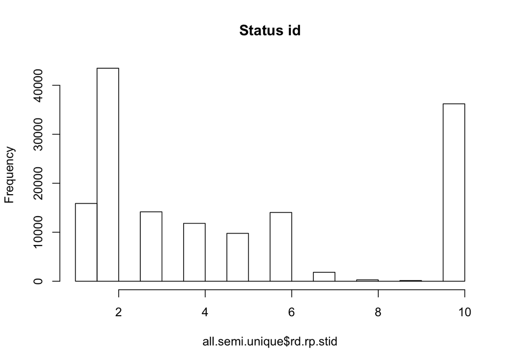

```r
hist(all.semi.unique$rd.rp.stid, main = "Status id")
```

Which means that the status id 2 which means (“lazeez”) is the highest comment status

```r
h = all.semi.unique  %>% filter(rd.rp.stid < 6) %>% mutate( hour = as.POSIXlt(actual_date)$hour) %>%group_by(hour) %>% summarize(mean=mean(rd.rp.stid)) %>% arrange(desc(mean))
h
```

```
## Source: local data frame [24 x 2]
##
##     hour     mean
##    (int)    (dbl)
## 1     16 3.007313
## 2     15 2.993828
## 3     14 2.822213
## 4     17 2.791640
## 5     13 2.728299
## 6      6 2.650691
## 7     18 2.613667
## 8     12 2.561248
## 9      7 2.419087
## 10    19 2.396762
## ..   ...      ...
```

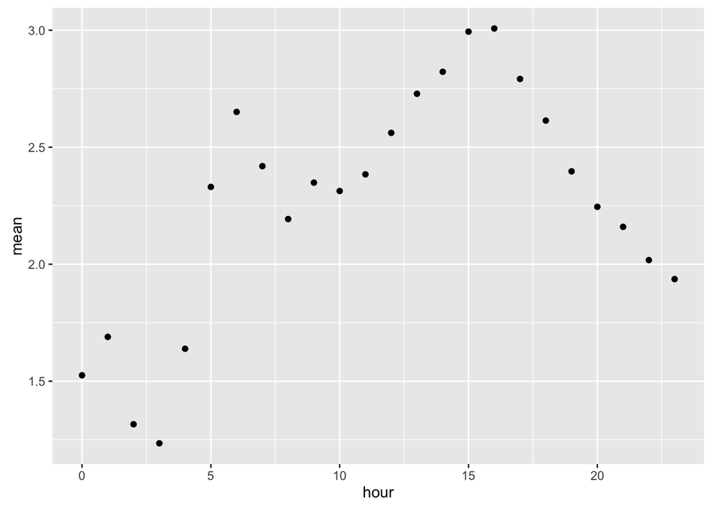

```r
qplot(x = hour, y = mean, data = h)
```

Ploting the highest congested hour

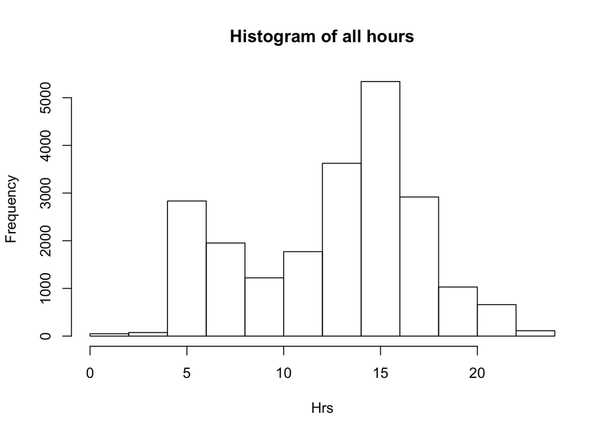

```r
hist(as.numeric(as.POSIXlt(all.semi.unique$actual_date)$hour[all.semi.unique$rd.rp.stid == 4|all.semi.unique$rd.rp.stid == 5]), main = "Histogram of all hours",xlab="Hrs")
```

Finding the the highest road reported:

```r
highest_road_reported = (all.semi.unique %>% group_by(rd.nm) %>% summarize(s=length(rd.rp.cmid)) %>% arrange(desc(s)))$rd.nm
head(highest_road_reported)
```

```
## [1] "Kobry 6 October;Madinet Nasr To Ta7rir"
## [2] "Da2ery;Moneeb To Autostrad"
## [3] "Da2ery;Autostrad To Moneeb"
## [4] "Kobry 6 October;Mohandesin To Ta7rir"
## [5] "Sa7rawy;Alex To Cairo"
## [6] "Sa7rawy;Cairo To Alex"
```

To find the highest congested road we can not use mean of the road status only as we need to consider the number of the comments:

```r
road_reported = all.semi.unique %>% filter(rd.rp.stid < 6) %>% group_by(rd.nm, rd.rp.stid) %>% summarize(s=length(rd.rp.cmid))
```

Then we can get the wighted mean by calculating the mean of the sum of each status of the road divided by the number of all comments which multiplied by the road status value:

```r
sum_of_all_comments = nrow(road_reported)
weighted_congestion_of_road = road_reported %>% mutate(ws = (s/sum_of_all_comments*rd.rp.stid)) %>% group_by(rd.nm) %>% summarize(mean = mean(ws)) %>% arrange(desc(mean))
head(weighted_congestion_of_road)
```

```
## Source: local data frame [6 x 2]
##
##                                    rd.nm      mean
##                                    (chr)     (dbl)
## 1 Kobry 6 October;Madinet Nasr To Ta7rir 1.0689446
## 2             Da2ery;Autostrad To Moneeb 0.7998481
## 3      Da2ery;Waslet Maryoutia To Moneeb 0.6587699
## 4               Me7war;Sa7rawy To Da2ery 0.6098709
## 5             Da2ery;Moneeb To Autostrad 0.6082005
## 6 Kobry 6 October;Ta7rir To Madinet Nasr 0.6022779
```

Plotting the mean status id for each road:

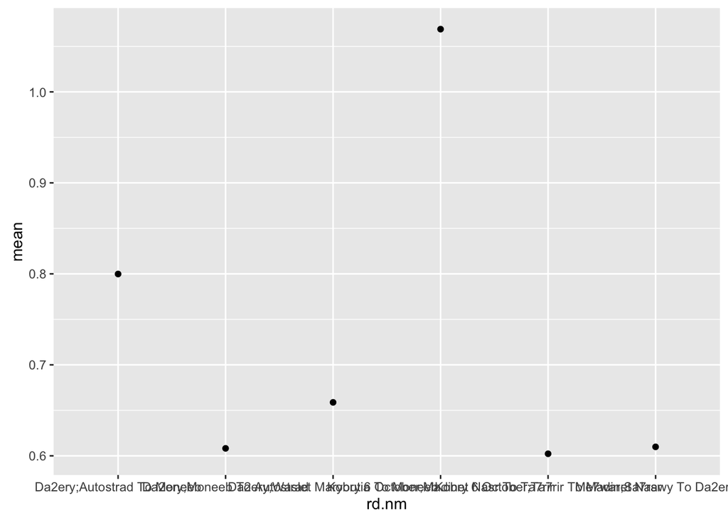

```r
qplot(x = rd.nm, y=mean, data =head(weighted_congestion_of_road))
```

To extract the speed of each road we filter the gps comments:

```r
gps_rows = all.semi.unique %>% filter(rd.rp.nm == "bey2ollakgps")
```

Then we add a new column represents the extracted speed from the gps comment:

```r
gps_rows$gps <-NA
gps_rows$gps <- regmatches(gps_rows$rd.rp.cm, gregexpr("[[:digit:]]+ km/h", gps_rows$rd.rp.cm, perl=T))
head(gps_rows)
```

```
##                                        rd.nm rd.ri rd.stid rd.new rd.strq
## 1 Makram 3ebeid;Autostrad To Mostafa ElNa7as   678       2      1       1
## 2 Makram 3ebeid;Autostrad To Mostafa ElNa7as   678       2      1       1
## 3 Makram 3ebeid;Autostrad To Mostafa ElNa7as   678       2      1       1
## 4 Makram 3ebeid;Autostrad To Mostafa ElNa7as   678       2      1       1
## 5     ElGhorfa ElTogareya;Ba7ary To Mansheya   321      NA      0       1
## 6     ElGhorfa ElTogareya;Ba7ary To Mansheya   321       2      0       1
##   rd.cmrq     rd.rp.nm rd.rp.stid
## 1       0 bey2ollakgps          3
## 2       0 bey2ollakgps          3
## 3       0 bey2ollakgps          4
## 4       0 bey2ollakgps          2
## 5       0 bey2ollakgps         10
## 6       0 bey2ollakgps         10
##                                                                              rd.rp.cm
## 1                                       الطريق أخد حوالي [4 ق] ومتوسط سرعته [23 كم/س]
## 2                                   Overall took [4 min] with average speed [23 km/h]
## 3                                       الطريق أخد حوالي [6 ق] ومتوسط سرعته [16 كم/س]
## 4                                   Overall took [2 min] with average speed [50 km/h]
## 5 From [Game3 Abo El3abas] to [ElMansheya] took [2 mins] with average speed [40 km/h]
## 6 From [Game3 Abo El3abas] to [ElMansheya] took [3 mins] with average speed [21 km/h]
##   rd.rp.cmid rd.rp.img         actual_date           road_date     gps
## 1    9302773     62923 2016-02-05 14:38:00 2016-02-06 14:05:00
## 2    9302649     62923 2016-02-05 14:18:00 2016-02-06 14:05:00 23 km/h
## 3    9359324     62923 2016-02-12 15:11:00 2016-02-13 14:26:00
## 4    9401353     62923 2016-02-17 00:44:00 2016-02-17 21:57:00 50 km/h
## 5    9327930     62923 2016-02-08 20:19:00 2016-02-09 16:52:00 40 km/h
## 6    9358086     62923 2016-02-12 12:15:00 2016-02-13 11:37:00 21 km/h
```

Then we extract the speed number from the new column: